# Práctica 4-II - Ejercicio 8

(ANCOVA) En el archivo Biomasa.xls se tienen datos correspondientes a un estudio en el que se muestrearon 3 tipos de vegetación en 3 localidades. En total se tomaron 45 observaciones. Se analizan lasvariables del sustrato:

- X: Ph
- Y: Biomasa aérea

# Item a

- Graficar la variable Y vs X, usando diferente color para las distintas localidades.

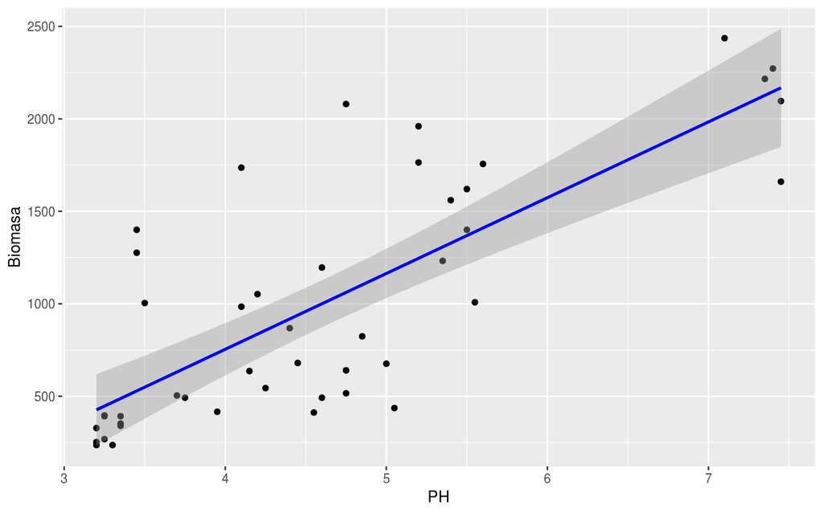

```r
df = read_excel("~/code/Modelo_Lineal_2019/ejercicios/Biomasa.xls")

ggplot(df, aes(y=df$BIO, x=df$PH)) + geom_point() +
  stat_smooth(method="lm", col="blue") + ylab("Biomasa") + xlab("PH")
```

```r
reg1 = lm(df$BIO~df$PH)
 summary(reg1)
```

```
##
## Call:
## lm(formula = df$BIO ~ df$PH)
##
## Residuals:
##     Min      1Q  Median      3Q     Max
## -748.30 -258.42  -95.63  216.03 1018.64
##
## Coefficients:
##             Estimate Std. Error t value Pr(>|t|)
## (Intercept)  -885.21     243.44  -3.636 0.000735 ***
## df$PH         409.80      51.09   8.021 4.43e-10 ***
## ---
## Signif. codes:  0 '***' 0.001 '**' 0.01 '*' 0.05 '.' 0.1 ' ' 1
##
## Residual standard error: 422.6 on 43 degrees of freedom
## Multiple R-squared:  0.5994, Adjusted R-squared:   0.59
## F-statistic: 64.33 on 1 and 43 DF,  p-value: 4.433e-10
```

La regresión no es muy buena pues no puede explicar la varianza de los datos. Esto resulta evidente al mirar el gráfico anterior, además el coeficiente de determinación $R^2 \approx 0.6$ sustenta esta conclusión.

De todas formas, la regresión es significativa. Como el conjunto de datos tiene más columnas, quizá sea relevante incluir alguna otra.

# Item b

* Realizar un ajuste del modelo completo utilizando la localidad como factor. ¿Qué observa?

⚠ ¿qué significa “modelo completo”? Hay dos variables categóricas y en el enunciado sólo me piden que use una ¿de qué forma esto es completo?

```r
head(df)
```

```
## # A tibble: 6 x 8
##     BIO     K  SODIO    PH   SAL    ZN   LOC  TYPE
##   <dbl> <dbl>  <dbl> <dbl> <dbl> <dbl> <dbl> <dbl>
## 1   676 1442. 35184.  5       33  16.5     1     1
## 2   516 1299. 28170.  4.75    35  14.0     1     1
## 3  1052 1154. 26455   4.2     32  15.3     1     1
## 4   868 1045. 25073.  4.4     30  17.3     1     1
## 5  1008  522. 31664.  5.55    33  22.3     1     1
## 6   436 1273  25492.  5.05    33  12.3     1     2
```

### Anova de 1 factor

Voy a hacer la asumpción mínima sobre el enunciado: considerar sólo un factor como covariable.

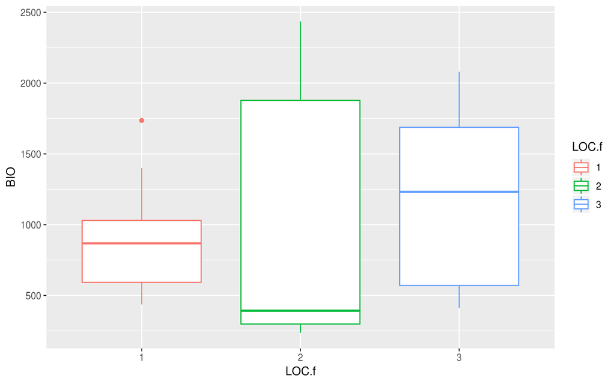

```r
df = cbind(df, LOC.f=factor(df$LOC))
ggplot(df, aes(y=BIO, x=LOC.f, color=LOC.f)) +  geom_boxplot()
```

Evidentemente la localidad no es una variable que explique satisfactoriamente la varianza en la biomasa. Asumo que cuando el enunciado se refiere a **modelo completo** sugiere utilizar otras covariables.

### Una variable categórica (LOC) y variable contínua (PH)

- La variable PH es contínua
- La variable LOC es categórica con 3 niveles

Voy a plantear un modelo con la siguiente notación:

- $P \equiv PH$
- $L_i : LOC = i$

Entonces para cada una de las localidades voy a tener una recta completamente distinta:

- L_1): $BIO = \mu + \alpha P$
- L_2): $BIO = \mu + \beta_2 + (\alpha + \gamma_2)P$
- L_3): $BIO = \mu + \beta_3 + (\alpha + \gamma_3)P$

con $\beta_1 = \gamma_1 = 0$. De esta forma tenemos 6 parámetros para estimar.

$$Y = \mu + \alpha P + \beta_i L_i + \gamma_i \cdot L_i PH$$

```r
df = data.frame(fastDummies::dummy_cols(df, select_columns="LOC.f", remove_first_dummy=T))
reg2 = lm(df$BIO~ df$LOC.f_2*df$PH + df$LOC.f_3*df$PH, data=df)
summary(reg2)
```

```
##
## Call:
## lm(formula = df$BIO ~ df$LOC.f_2 * df$PH + df$LOC.f_3 * df$PH,
##     data = df)
##
## Residuals:
##     Min      1Q  Median      3Q     Max
## -600.70 -176.47  -10.24   86.62  927.22
##
## Coefficients:
##                  Estimate Std. Error t value Pr(>|t|)
## (Intercept)        2401.3      603.0   3.982 0.000289 ***
## df$LOC.f_2        -3525.1      638.6  -5.520 2.40e-06 ***
## df$PH              -346.2      136.6  -2.533 0.015427 *
## df$LOC.f_3        -4575.3      857.9  -5.333 4.36e-06 ***
## df$LOC.f_2:df$PH    788.6      142.9   5.518 2.42e-06 ***
## df$PH:df$LOC.f_3   1046.5      185.8   5.632 1.68e-06 ***
## ---
## Signif. codes:  0 '***' 0.001 '**' 0.01 '*' 0.05 '.' 0.1 ' ' 1
##
## Residual standard error: 312.8 on 39 degrees of freedom
## Multiple R-squared:  0.801,  Adjusted R-squared:  0.7755
## F-statistic:  31.4 on 5 and 39 DF,  p-value: 1.102e-12
```

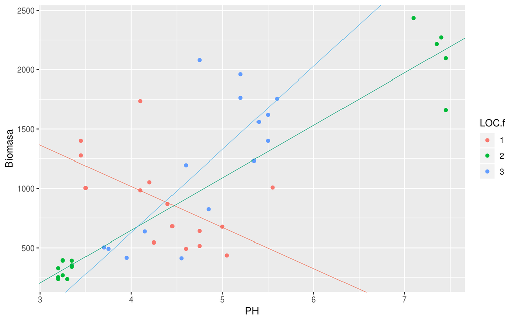

```r
ggplot(df, aes(y=df$BIO, x=df$PH, colour=LOC.f)) + geom_point() + ylab("Biomasa") + xlab("PH") +
geom_abline(intercept = reg2$coefficients[1],
            slope = reg2$coefficients[3],
            color="coral2", linetype="solid", size=.25) +
geom_abline(intercept = reg2$coefficients[1] + reg2$coefficients[2] ,
            slope = reg2$coefficients[3] + reg2$coefficients[5],
            color="#009E73", linetype="solid", size=.25) +
geom_abline (intercept = reg2$coefficients[1] +reg2$coefficients[4],
             slope = reg2$coefficients[3] + reg2$coefficients[6],
             color="#56B4E9", linetype="solid", size=.25)
```

Evidentemente un $R^2 \approx 0.8$ evidencia una mejora significativa en la regresión. Además se nota el efecto de considerar distntas ordenadas al origen y pendientes. Quiza para los niveles 2 y 3 no fueran necesarias dos ordenadas al origen distintas.

### Test F

$$F = \frac{(A\hat{\beta} - c)'[A(X'X)^{-1}A']^{-1}(A\hat{\beta}-c)}{qS^2} \sim \mathcal{F}_{q, n-p}$$
En este caso $n=45$, $p=6$, $q=1$ pues $A=(0,1,0,-1,0,0)$, y $c=0$, entonces:

$$F = \frac{(\hat\beta_2 - \hat\beta_3)'[(0,1,0,-1,0,0)(X'X)^{-1}(0,1,0,-1,0,0)']^{-1}(\hat\beta_2 - \hat\beta_3)}{S^2} \sim \mathcal{F}_{1, 39}$$

```r
# F test
X = model.matrix(reg2)
B_hat = reg2$coefficients
A = matrix(
    c(0, 1, 0, -1, 0, 0),
    nrow=1,
    ncol=6,
    byrow=T
)

F_h0 = ((A %*% B_hat) * solve(A %*% solve(t(X) %*% X) %*% t(A)) %*% (A %*% B_hat)) / (nrow(A) * summary(reg2)$sigma^2)
p_value = pf(F_h0, df1=nrow(A), df2=nrow(X)-ncol(A), lower.tail=F)
```

El test F nos da un p-valor $p 0.11 $, es decir que la probabilidad de obtener el valor realizado en el estadístico F algo baja si consideramos la hipótesis nula $\beta_2 = \beta_3$ como cierta.

Entonces sería interesante probar un modelo con una variable cuantitativa (?) regresora menos:

- L_1): $BIO = \mu_1 + \alpha P$
- L_2): $BIO = \mu + (\alpha + \gamma_2)P$
- L_3): $BIO = \mu + (\alpha + \gamma_3)P$

$$Y = \mu + \alpha P + \beta_i L_i + \gamma_i \cdot L_i PH$$

```r
df2 = data.frame(fastDummies::dummy_cols(df, select_columns="LOC.f"))
reg3 = lm(df2$BIO~ df2$LOC.f_2*df2$PH + df2$LOC.f_3*df2$PH - df2$LOC.f_3 - df2$LOC.f_2 + df2$LOC.f_1, data=df2)
summary(reg3)
```

```
##
## Call:
## lm(formula = df2$BIO ~ df2$LOC.f_2 * df2$PH + df2$LOC.f_3 * df2$PH -
##     df2$LOC.f_3 - df2$LOC.f_2 + df2$LOC.f_1, data = df2)
##
## Residuals:
##     Min      1Q  Median      3Q     Max
## -665.79 -180.93    5.46   92.80  900.54
##
## Coefficients:
##                    Estimate Std. Error t value Pr(>|t|)
## (Intercept)         -1235.2      202.9  -6.088 3.55e-07 ***
## df2$PH               -346.2      139.4  -2.483   0.0173 *
## df2$LOC.f_1          3636.5      647.9   5.613 1.65e-06 ***
## df2$LOC.f_2:df2$PH    809.1      145.3   5.570 1.90e-06 ***
## df2$PH:df2$LOC.f_3    854.5      146.5   5.835 8.07e-07 ***
## ---
## Signif. codes:  0 '***' 0.001 '**' 0.01 '*' 0.05 '.' 0.1 ' ' 1
##
## Residual standard error: 319.1 on 40 degrees of freedom
## Multiple R-squared:  0.7875, Adjusted R-squared:  0.7663
## F-statistic: 37.06 on 4 and 40 DF,  p-value: 5.9e-13
```

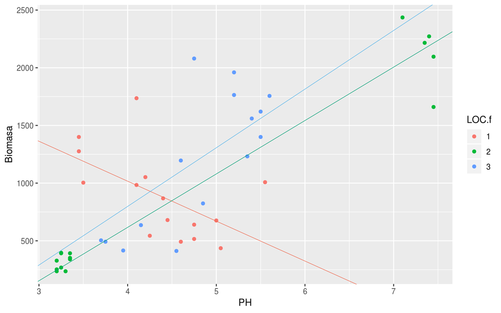

```r
coefs = reg3$coefficients
ggplot(df2, aes(y=df2$BIO, x=df2$PH, colour=LOC.f)) + geom_point() + ylab("Biomasa") + xlab("PH") +

geom_abline(intercept = coefs[1] + coefs[3] ,
            slope = coefs[2],
            color="coral2", linetype="solid", size=.25) +
geom_abline(intercept = coefs[1] ,
            slope = coefs[2] + coefs[4],
            color="#009E73", linetype="solid", size=.25) +
geom_abline (intercept = coefs[1],
             slope = coefs[5] + coefs[2],
             color="#56B4E9", linetype="solid", size=.25)
```

El test arroja un pvalor de 0.11, es decir la probabilidad de haber obtenido el valor del estadístico $F$ si la hipótesis nula (los coeficientes $\beta_2$ y $\beta_3$ son iguales) es cierta. El valor no es suficiente para rechazar esta $H_0$ con una confianza mayor al 90%.

# Item c y d

* Realizar un ajuste utilizando el modelo aditivo. ¿Qué observa? * Evaluar el efecto de la localidad en el modelo aditivo.

```r
reg4 = lm(df$BIO ~ df$LOC.f_2 + df$LOC.f_3 + df$PH, data=df)
summary(reg4)
```

```
##
## Call:
## lm(formula = df$BIO ~ df$LOC.f_2 + df$LOC.f_3 + df$PH, data = df)
##
## Residuals:
##    Min     1Q Median     3Q    Max
## -725.2 -289.8  -55.0  207.1  959.1
##
## Coefficients:
##             Estimate Std. Error t value Pr(>|t|)
## (Intercept)  -881.70     251.86  -3.501  0.00113 **
## df$LOC.f_2    -66.50     155.56  -0.427  0.67128
## df$LOC.f_3    128.72     156.59   0.822  0.41583
## df$PH         404.53      51.85   7.802 1.25e-09 ***
## ---
## Signif. codes:  0 '***' 0.001 '**' 0.01 '*' 0.05 '.' 0.1 ' ' 1
##
## Residual standard error: 424.5 on 41 degrees of freedom
## Multiple R-squared:  0.6147, Adjusted R-squared:  0.5865
## F-statistic:  21.8 on 3 and 41 DF,  p-value: 1.337e-08
```

En principio el $R^2 \approx 0.61$ es mucho menor que el obtenido en con los dos modelos anteriores, incluso para aquel que suponía una sóla ordenada al origen para los niveles 2 y 3 de LOC.

# Item e

Mariano Barraco marianobarraco@gmail.com

2019-06-26